# DESeq2 vs DESeq2 + ZINB-WaVE for inDrop data

# Differential expression

## with weights

```r
contrast = c("genoregion", "mutant_anterior", "wt_anterior")
dds_g0_weights = DESeq(dds_g0_weights, test="LRT", full=~1+genoregion, reduced=~1,
                       sfType="poscounts", minmu=1e-6, minRep=Inf)
```

```
## -- note: fitType='parametric', but the dispersion trend was not well captured by the
##    function: y = a/x + b, and a local regression fit was automatically substituted.
##    specify fitType='local' or 'mean' to avoid this message next time.
```

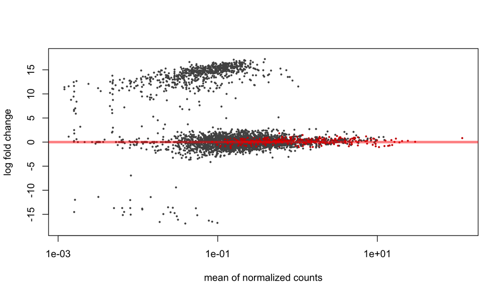

```r
g0_weights_results = results(dds_g0_weights, contrast=contrast, cooksCutoff=FALSE)
plotMA(g0_weights_results)
```

## without weights

```r
dds_g0_noweights = DESeq(dds_g0_noweights, test="LRT", full=~1+genoregion, reduced=~1,
                       sfType="poscounts", minmu=1e-6, minRep=Inf)
```

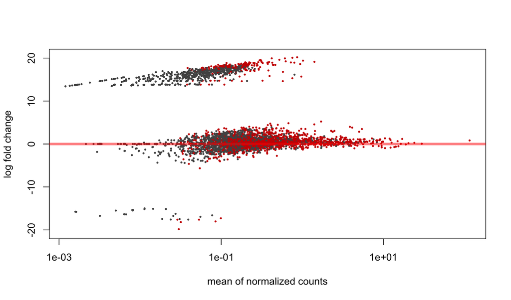

```r
g0_noweights_results = results(dds_g0_noweights, contrast=contrast, cooksCutoff=FALSE)
plotMA(g0_noweights_results)
```

# Comparison of DESeq2 and DESeq2 + ZINB-WaVE

The p-values aren’t really correlated to each other across much of the range, but the LFCs are:

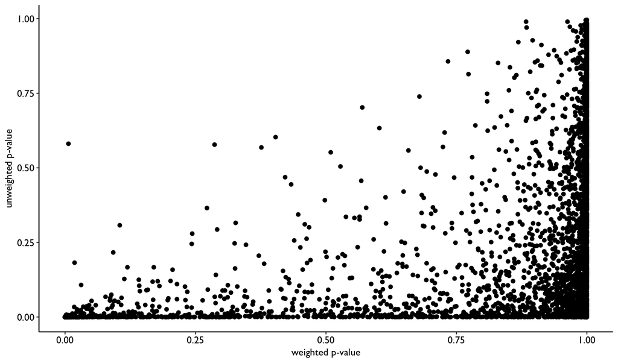

```r
results = data.frame(symbol=rownames(g0_weights_results),
                     baseMean=g0_weights_results$baseMean,
                     weights_pval=g0_weights_results$pvalue,
                     weights_padj=g0_weights_results$padj,
                     weights_lfc=g0_weights_results$log2FoldChange,
                     weights_lfcSE=g0_weights_results$lfcSE,
                     noweights_pval=g0_noweights_results$pvalue,
                     noweights_lfc=g0_noweights_results$log2FoldChange,
                     noweights_lfcSE=g0_noweights_results$lfcSE,
                     noweights_padj=g0_noweights_results$padj)
ggplot(results, aes(weights_pval, noweights_pval)) +
  geom_point() +
  xlab("weighted p-value") +
  ylab("unweighted p-value")
```

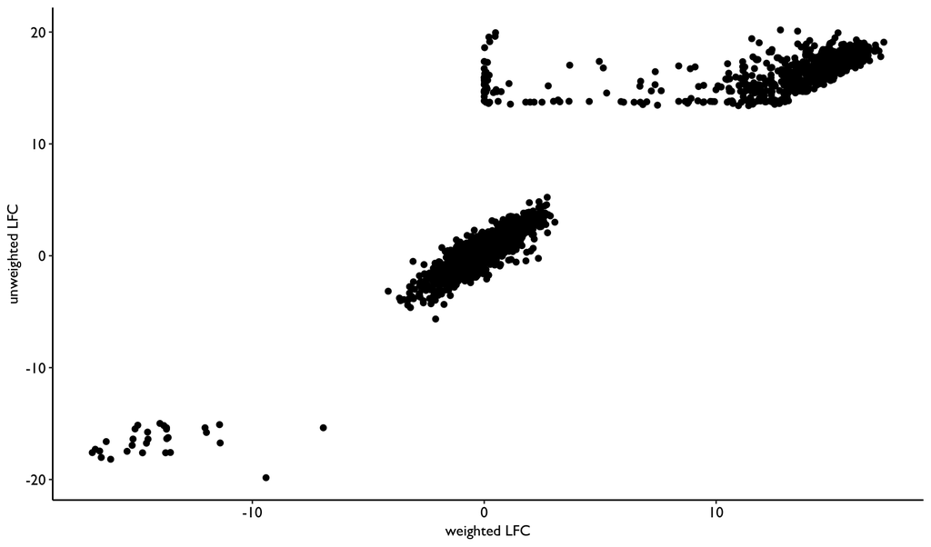

```r
ggplot(results, aes(weights_lfc, noweights_lfc)) +
  geom_point() +
  xlab("weighted LFC") +
  ylab("unweighted LFC")
```

```r
weighted_siggenes = subset(results, weights_padj < 0.05)$symbol
noweighted_siggenes = subset(results, noweights_padj < 0.05)$symbol
allsig = union(weighted_siggenes, noweighted_siggenes)
both = intersect(weighted_siggenes, noweighted_siggenes)
weighted_specific = weighted_siggenes[!weighted_siggenes %in% noweighted_siggenes]
noweighted_specific = noweighted_siggenes[!noweighted_siggenes %in% weighted_siggenes]
```

The unweighted results are a superset of the weighted results.

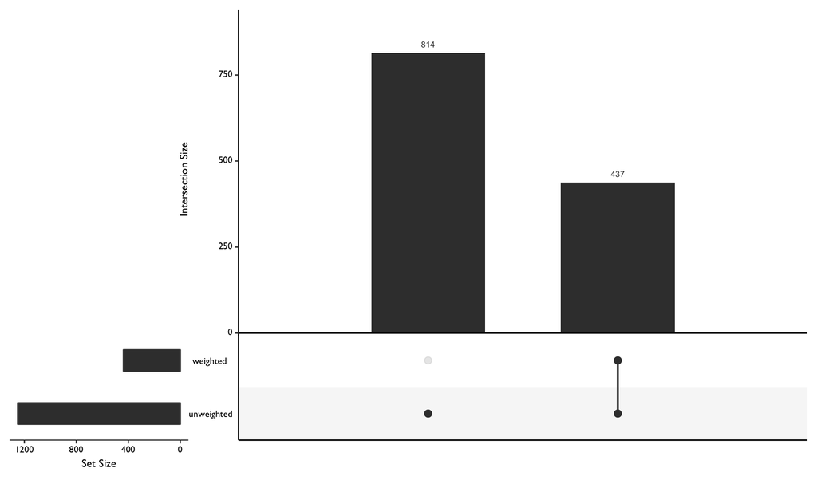

```r
setinfo = list(weighted=weighted_siggenes, unweighted=noweighted_siggenes)
UpSetR::upset(fromList(setinfo))
```

```r
results$present = ifelse(results$symbol %in% both, "both",
                         ifelse(results$symbol %in% noweighted_specific,
                                "noweighted_specific", "notsig"))
```

The unweighted-specific genes are distributed across the baseMean spectrum, so it isn’t specifically low or high genes we are missing.

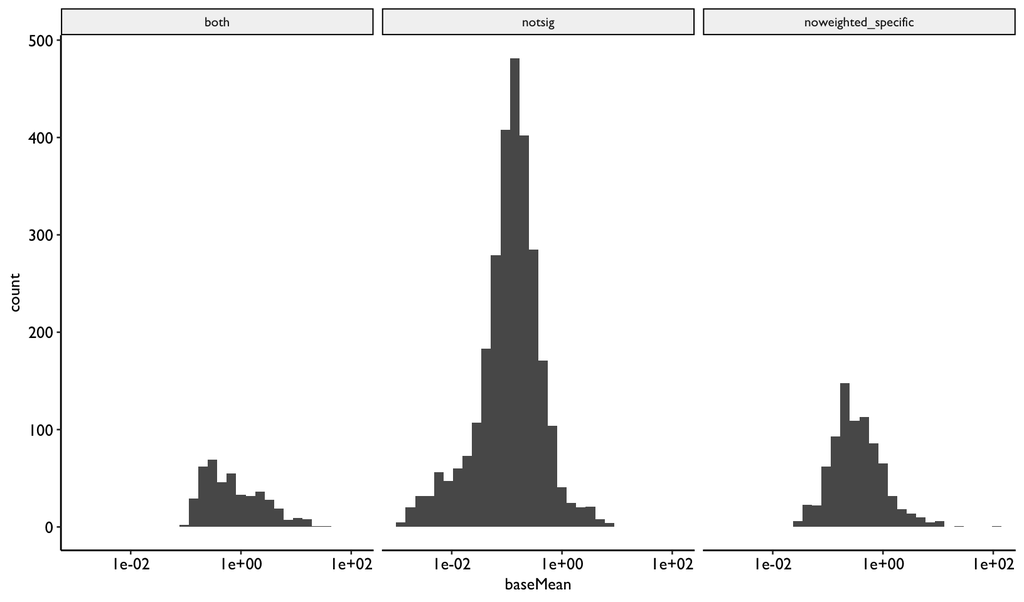

```r
ggplot(results, aes(baseMean)) +
  geom_histogram() +
  facet_wrap(~present) +
  scale_x_log10()
```

We are missing calls for large LFC genes with the ZINB-WaVE weighted calls, but there are differences across the spectrum.

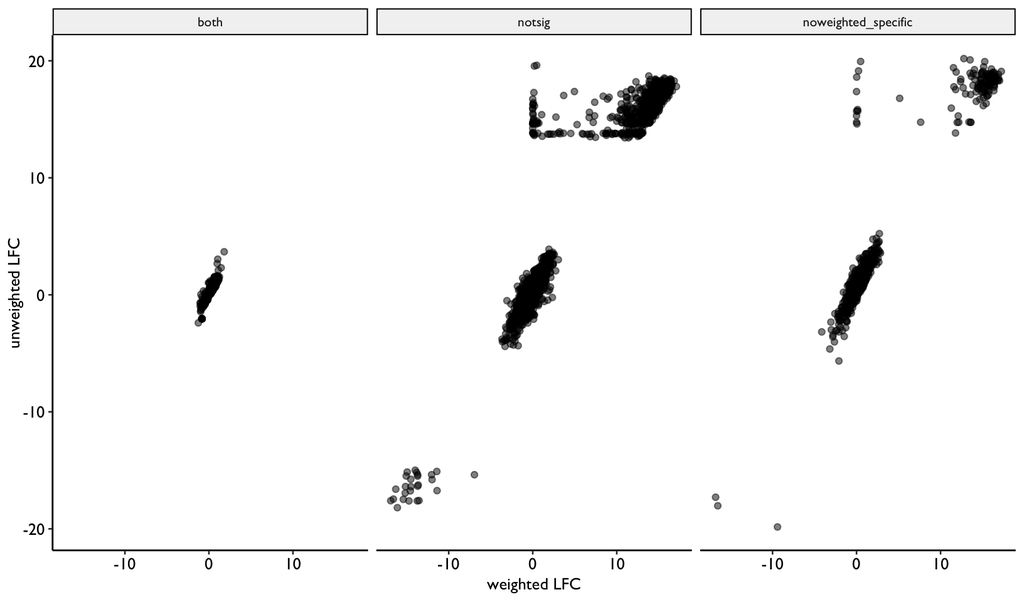

```r
ggplot(results, aes(weights_lfc, noweights_lfc)) +
  geom_point(alpha=0.5) +
  facet_wrap(~present) +
  xlab("weighted LFC") +
  ylab("unweighted LFC")
```

It’s possible that DESeq2 is calling too liberally with no weights and too strict with ZINB-WaVE weights though.

# low baseMean, high LFC genes

I selected genes with a LFC > 10 and a baseMean > 0.3. If we include all of the facets, these don’t look super impressive:

```r
low = as.character(subset(results, abs(noweights_lfc) > 10 & baseMean > 0.3)$symbol)
lowdat = counts(dds_g0_noweights)[low,] %>%
  as.data.frame() %>%
  tibble::rownames_to_column("symbol") %>%
  gather(cell, UMI, -symbol) %>%
  left_join(colData(dds_noweights) %>%
            as.data.frame() %>%
            tibble::rownames_to_column("cell")) %>%
  left_join(results)
```

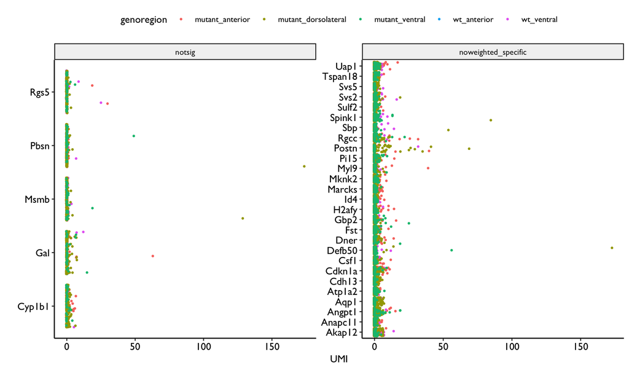

```r
ggplot(lowdat, aes(symbol, UMI, color=genoregion)) +
  coord_flip() +
  geom_jitter(size=0.5)  +
  xlab("") +
  facet_wrap(~present, scale="free")
```

But if we subset down to just the contrasts we are interested in, they do look like they should be called DE, and DESeq2 alone calls most of these.

```r
lowdat = counts(dds_g0_noweights)[low,] %>%
  as.data.frame() %>%
  tibble::rownames_to_column("symbol") %>%
  gather(cell, UMI, -symbol) %>%
  left_join(colData(dds_noweights) %>%
            as.data.frame() %>%
            tibble::rownames_to_column("cell")) %>%
  dplyr::filter(genoregion %in% c("mutant_anterior", "wt_anterior")) %>%
  left_join(results)
```

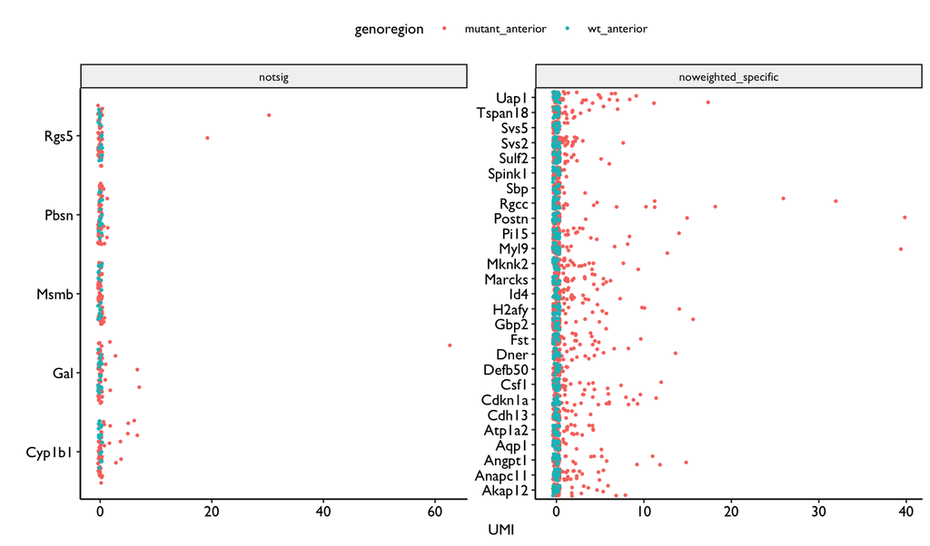

```r
ggplot(lowdat, aes(symbol, UMI, color=genoregion)) +
  coord_flip() +
  geom_jitter(size=0.5)  +
  xlab("") +
  facet_wrap(~present, scale="free")
```

# Summary

ZINB-WaVE weights are causing a lot of what appear to be false negatives to me in this inDrop dataset. There’s been some talk that there may not be a need to add a zero inflated component to experiments that use UMIs (see [this paper](https://www.biorxiv.org/content/early/2018/08/17/225177)) for example.

# Links to raw data

[Seurat object](https://www.dropbox.com/s/xa9xql7pjx9l7tb/seurat.rda?dl=1)

[DDS object, no weights](https://www.dropbox.com/s/pq5sogzyp7edz0y/dds-noweights.rda?dl=1)

[DDS object, with weights](https://www.dropbox.com/s/kh3yoyxg5outybx/dds-weights.rda?dl=1)